# Bikes

## by Scott Smith

This data set includes information about individual rides made in a bike-sharing system covering the greater San Francisco Bay area.

```python
# import all packages and set plots to be embedded inline
import numpy as np
import pandas as pd
import matplotlib.pyplot as plt
import seaborn as sb

%matplotlib inline
```

```python
df = pd.read_csv('2017-fordgobike-tripdata.csv')
```

```python
df.head()
```

|  | duration_sec | start_time | end_time | start_station_id | start_station_name | start_station_latitude | start_station_longitude | end_station_id | end_station_name | end_station_latitude | end_station_longitude | bike_id | user_type | member_birth_year | member_gender |
| --- | --- | --- | --- | --- | --- | --- | --- | --- | --- | --- | --- | --- | --- | --- | --- |
| 0 | 80110 | 57:39.7 | 12:50.2 | 74 | Laguna St at Hayes St | 37.776435 | -122.426244 | 43 | San Francisco Public Library (Grove St at Hyde... | 37.778768 | -122.415929 | 96 | Customer | 1987.0 | Male |
| 1 | 78800 | 56:34.8 | 49:55.6 | 284 | Yerba Buena Center for the Arts (Howard St at ... | 37.784872 | -122.400876 | 96 | Dolores St at 15th St | 37.766210 | -122.426614 | 88 | Customer | 1965.0 | Female |
| 2 | 45768 | 45:48.4 | 28:36.9 | 245 | Downtown Berkeley BART | 37.870348 | -122.267764 | 245 | Downtown Berkeley BART | 37.870348 | -122.267764 | 1094 | Customer | NaN | NaN |
| 3 | 62172 | 31:10.6 | 47:23.5 | 60 | 8th St at Ringold St | 37.774520 | -122.409449 | 5 | Powell St BART Station (Market St at 5th St) | 37.783899 | -122.408445 | 2831 | Customer | NaN | NaN |
| 4 | 43603 | 23:14.0 | 29:57.6 | 239 | Bancroft Way at Telegraph Ave | 37.868813 | -122.258764 | 247 | Fulton St at Bancroft Way | 37.867789 | -122.265896 | 3167 | Subscriber | 1997.0 | Female |

```python
print(df.info())
print(df.describe())
```

```
<class 'pandas.core.frame.DataFrame'>
RangeIndex: 519700 entries, 0 to 519699
Data columns (total 15 columns):
duration_sec               519700 non-null int64
start_time                 519700 non-null object
end_time                   519700 non-null object
start_station_id           519700 non-null int64
start_station_name         519700 non-null object
start_station_latitude     519700 non-null float64
start_station_longitude    519700 non-null float64
end_station_id             519700 non-null int64
end_station_name           519700 non-null object
end_station_latitude       519700 non-null float64
end_station_longitude      519700 non-null float64
bike_id                    519700 non-null int64
user_type                  519700 non-null object
member_birth_year          453159 non-null float64
member_gender              453238 non-null object
dtypes: float64(5), int64(4), object(6)
memory usage: 47.6+ MB
None
        duration_sec  start_station_id  start_station_latitude  \
count  519700.000000     519700.000000           519700.000000
mean     1099.009521         95.034245               37.771653
std      3444.146451         86.083078                0.086305
min        61.000000          3.000000               37.317298
25%       382.000000         24.000000               37.773492
50%       596.000000         67.000000               37.783521
75%       938.000000        139.000000               37.795392
max     86369.000000        340.000000               37.880222

       start_station_longitude  end_station_id  end_station_latitude  \
count            519700.000000   519700.000000         519700.000000
mean               -122.363927       92.184041             37.771844
std                   0.105573       84.969491              0.086224
min                -122.444293        3.000000             37.317298
25%                -122.411726       23.000000             37.774520
50%                -122.398870       66.000000             37.783830
75%                -122.391034      134.000000             37.795392
max                -121.874119      340.000000             37.880222

       end_station_longitude        bike_id  member_birth_year
count          519700.000000  519700.000000      453159.000000
mean             -122.363236    1672.533079        1980.404787
std                 0.105122     971.356959          10.513488
min              -122.444293      10.000000        1886.000000
25%              -122.410345     787.000000        1974.000000
50%              -122.398525    1728.500000        1983.000000
75%              -122.391034    2520.000000        1988.000000
max              -121.874119    3733.000000        1999.000000
```

```python
df_cleaned = df.dropna()
```

```python
df_cleaned.head()
```

|  | duration_sec | start_time | end_time | start_station_id | start_station_name | start_station_latitude | start_station_longitude | end_station_id | end_station_name | end_station_latitude | end_station_longitude | bike_id | user_type | member_birth_year | member_gender |
| --- | --- | --- | --- | --- | --- | --- | --- | --- | --- | --- | --- | --- | --- | --- | --- |
| 0 | 80110 | 57:39.7 | 12:50.2 | 74 | Laguna St at Hayes St | 37.776435 | -122.426244 | 43 | San Francisco Public Library (Grove St at Hyde... | 37.778768 | -122.415929 | 96 | Customer | 1987.0 | Male |
| 1 | 78800 | 56:34.8 | 49:55.6 | 284 | Yerba Buena Center for the Arts (Howard St at ... | 37.784872 | -122.400876 | 96 | Dolores St at 15th St | 37.766210 | -122.426614 | 88 | Customer | 1965.0 | Female |
| 4 | 43603 | 23:14.0 | 29:57.6 | 239 | Bancroft Way at Telegraph Ave | 37.868813 | -122.258764 | 247 | Fulton St at Bancroft Way | 37.867789 | -122.265896 | 3167 | Subscriber | 1997.0 | Female |
| 6 | 4507 | 49:28.4 | 04:35.6 | 259 | Addison St at Fourth St | 37.866249 | -122.299371 | 259 | Addison St at Fourth St | 37.866249 | -122.299371 | 3539 | Customer | 1991.0 | Female |
| 12 | 2183 | 52:55.6 | 29:18.7 | 67 | San Francisco Caltrain Station 2 (Townsend St... | 37.776639 | -122.395526 | 24 | Spear St at Folsom St | 37.789677 | -122.390428 | 2311 | Subscriber | 1990.0 | Male |

```python
df_cleaned.info()
```

```
<class 'pandas.core.frame.DataFrame'>
Int64Index: 453159 entries, 0 to 519699
Data columns (total 15 columns):
duration_sec               453159 non-null int64
start_time                 453159 non-null object
end_time                   453159 non-null object
start_station_id           453159 non-null int64
start_station_name         453159 non-null object
start_station_latitude     453159 non-null float64
start_station_longitude    453159 non-null float64
end_station_id             453159 non-null int64
end_station_name           453159 non-null object
end_station_latitude       453159 non-null float64
end_station_longitude      453159 non-null float64
bike_id                    453159 non-null int64
user_type                  453159 non-null object
member_birth_year          453159 non-null float64
member_gender              453159 non-null object
dtypes: float64(5), int64(4), object(6)
memory usage: 44.9+ MB
```

There were 519,700 records, but a lot of NAN's, so I cleaned up the file and now there are 453,159. There are 15 different characteristics about the ride and the riders.

1. The duration of the ride (how long are the customers using the bikes?)
2. Which gender rides more often? What age group rides most often?
3. Are they regular riders (subscriber) or just occasional (customer).

The main characteristics I will be investigating are - member gender, member birth year, user type and duration.

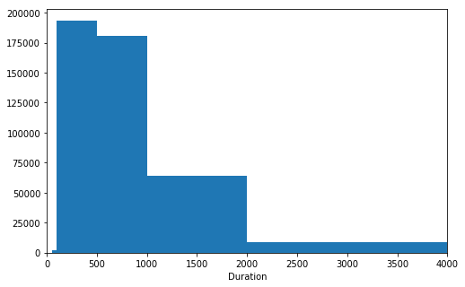

```python
x_values = [0, 50, 100, 500, 1000, 2000, 5000, 10000]
#binsize = 1000
#bins = np.arange(0, df_cleaned['duration_sec'].max()+binsize, binsize)

plt.figure(figsize=[8, 5])
plt.hist(data = df_cleaned, x = 'duration_sec',  bins = x_values)
plt.xlabel('Duration')
plt.xlim(0, 4000)
plt.show()
```

Because of the long tail to the right, I will try to use a log scale.

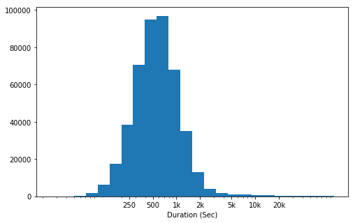

```python
log_binsize = .15
bins = 10 ** np.arange(1.4, np.log10(df_cleaned['duration_sec'].max())+log_binsize, log_binsize)

plt.figure(figsize=[8, 5])
plt.hist(data = df_cleaned, x = 'duration_sec', bins = bins)
plt.xscale('log')
plt.xticks([250, 500, 1e3, 2e3, 5e3, 1e4, 2e4], [250, 500, '1k', '2k', '5k', '10k', '20k'])
plt.xlabel('Duration (Sec)')
plt.show()
```

```python
df_cleaned['duration_sec'].mean()
```

```
832.9340143305109
```

Duration has a long-tailed distribution, with a few rides of a very long duration. Plotted with a log scale, it shows to be unimodel and peaking between 500 to 900 seconds (roughly 10 minute rides, about a 1/4 of the rides)

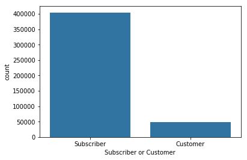

```python
base_color = sb.color_palette()[0]
cat_order = df_cleaned['user_type'].value_counts().index
sb.countplot(data = df_cleaned, x = 'user_type', color = base_color, order = cat_order)
plt.xlabel('Subscriber or Customer');
```

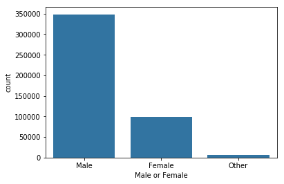

```python
base_color = sb.color_palette()[0]
cat_order = df_cleaned['member_gender'].value_counts().index
sb.countplot(data = df_cleaned, x = 'member_gender', color = base_color, order = cat_order)
plt.xlabel('Male or Female');
```

```python
df_cleaned['member_gender'].value_counts()
```

```
Male      348318
Female     98542
Other       6299
Name: member_gender, dtype: int64
```

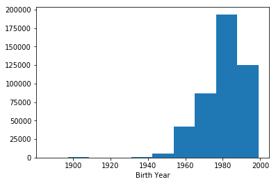

```python
plt.hist(df_cleaned['member_birth_year'])
plt.xlabel('Birth Year');
```

```python
df_cleaned['member_birth_year'].value_counts()
```

```
1985.0    24342
1988.0    23610
1987.0    22493
1984.0    21061
1982.0    21005
1986.0    20134
1983.0    19270
1989.0    19202
1990.0    16832
1991.0    16009
1981.0    15132
1980.0    14817
1993.0    13394
1979.0    12691
1992.0    11928
1977.0    11798
1975.0    11454
1978.0    10845
1994.0     9932
1973.0     9230
1974.0     9186
1968.0     9038
1976.0     8782
1965.0     7926
1971.0     7892
1970.0     7599
1967.0     6650
1972.0     6645
1995.0     6616
1969.0     6556
          ...
1957.0     1525
1955.0     1082
1952.0      960
1999.0      899
1951.0      745
1950.0      740
1953.0      596
1947.0      534
1949.0      500
1948.0      464
1945.0      280
1944.0      231
1902.0      217
1943.0      188
1900.0      142
1935.0      134
1946.0       82
1942.0       73
1924.0       66
1941.0       57
1933.0       41
1939.0       37
1934.0       34
1928.0       29
1940.0       29
1938.0       22
1911.0       12
1907.0        7
1901.0        4
1886.0        2
Name: member_birth_year, Length: 73, dtype: int64
```

The graphs shows an overwhelming number of Subscribers as compared to the random Customer, as well as male riders to female or other riders. They also show that the majority of the birth years were early to mid 1980's, with early 1990's as the next level.

I will now be using Bivariate plots to investigate the members gender in comparison to their birth year, as well as their gendr compared to rather they are subscribers or just a reagular customer. I will show how the age affected the duration of the rides.

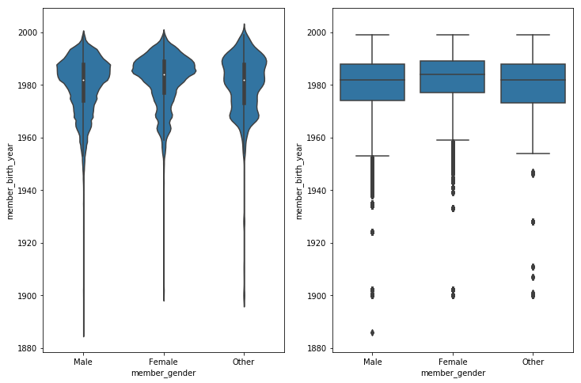

```python
plt.figure(figsize = [12, 8])
base_color = sb.color_palette()[0]

plt.subplot(1, 2, 1)
ax1 = sb.violinplot(data = df_cleaned, x = 'member_gender', y = 'member_birth_year', color = base_color)

plt.subplot(1, 2, 2)
sb.boxplot(data = df_cleaned, x = 'member_gender', y = 'member_birth_year', color = base_color)
plt.ylim(ax1.get_ylim()); # set y-axis limits to be same as left plot
```

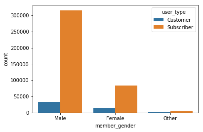

```python
sb.countplot(data = df_cleaned, x = 'member_gender', hue = 'user_type');
```

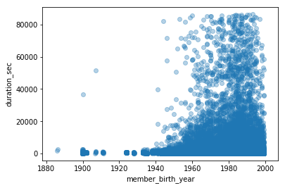

```python
sb.regplot(data = df_cleaned, x = 'member_birth_year', y = 'duration_sec', fit_reg = False,
           x_jitter = 0.2, y_jitter = 0.2, scatter_kws = {'alpha' : 1/3});
```

The Multivariate plots will break down the age and gender groups into more detail with user type and duration of rides.

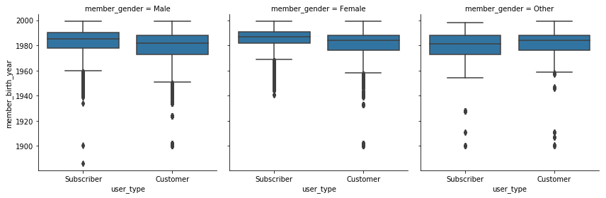

```python
g = sb.FacetGrid(data = df_cleaned, col = 'member_gender', size = 4)
g.map(sb.boxplot, 'user_type', 'member_birth_year');
```

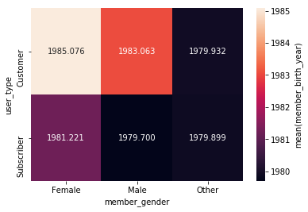

```python
cat_means = df.groupby(['member_gender', 'user_type']).mean()['member_birth_year']
cat_means = cat_means.reset_index(name = 'member_birth_year_avg')
cat_means = cat_means.pivot(index = 'user_type', columns = 'member_gender',
                            values = 'member_birth_year_avg')
sb.heatmap(cat_means, annot = True, fmt = '.3f',
           cbar_kws = {'label' : 'mean(member_birth_year)'});
```

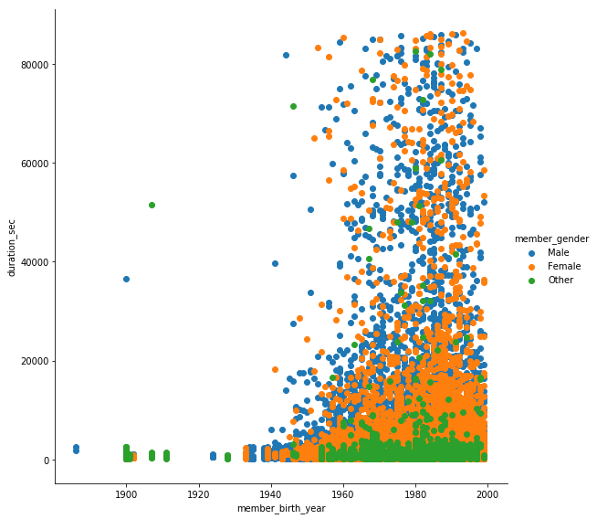

```python
g = sb.FacetGrid(data = df_cleaned, hue = 'member_gender', size = 8)
g.map(plt.scatter, 'member_birth_year','duration_sec')
g.add_legend();
```

While there are considerably more male riders to female, the longer duration rides show a fairly even amount of males and females taking the longer rides.